# Part II - Presentation of Key Insights from the Exploration of the Loan Data from Prosper Dataset

## by Ubogun O. Divine-Favour

## Investigation Overview

The investigation focuses on conveying certain insights obtained in the exploratory analysis of the loans in the Loan Data from Prosper dataset. The insights include:

1. Most loans taken for student use are usually completed.
2. High-income earners are more likely to take loans for debt consolidation.
3. Loans with longer loan lengths have a higher interest rate.
4. Borrowers who take high loan amounts are more likely to opt for long-term loans.
5. High-income earners are more likely to take high loan amounts.
6. Lower loan amounts for each loan length, are more likely to be defaulted or charged off.
7. For each loan length, loans with higher interest rates will likely get defaulted, charged off or not paid in time.

## Dataset Overview

The Loan Data from Prosper dataset originally has over 110,000 loan entries on 81 variables but was modified into only 14,882 loan entries on 13 variables for the analysis. The variables include the loan amount (**LoanOriginalAmount**), interest rate (**BorrowerRate**), loan length (**Term**), loan listing category (**ListingCategory**), loan status (**LoanStatus**), borrowers' income range (**IncomeRange**) and other characteristics of the borrowers.

## Percentage Proportion of Loan Status for Loans taken for Student Use

The bar chart below depicts the percentage proportion of each loan status for loans taken for student use. It shows that 75.34% of these student use loans are completed. Thereby indicating that most loans taken for student use are usually completed.

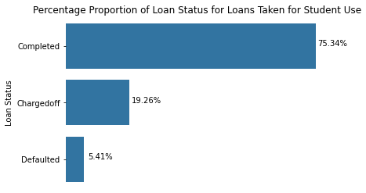

## Income Range Level Distribution for Debt Consolidation Loans.

The bar chart below shows the frequency or sum of borrowers who took loans for debt consolidation in their various income levels. In the bar chart, the number of high-income earners shown is far more than the number of low-income earners, which supports the finding that high-income earners are more likely to take loans for debt consolidation.

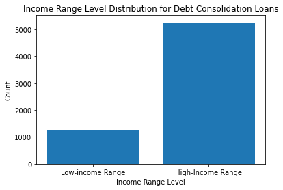

## Effect of Loan Length on Interest Rate

The point and violin plots created below depict the relationship between interest rate and loan length.

In the point plot, there is an obvious increase in the average interest rate from short term to long term. A similar progression is also seen in the violin plot, with more values distributed in higher interest rates as the loan length goes from short to long term, showing that longer-term loans have a higher interest rate.

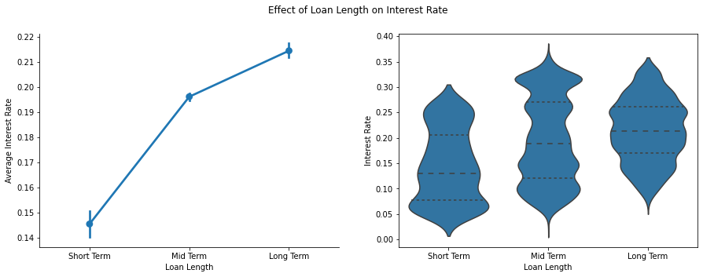

## Distribution of Loan Amount by Loan Length

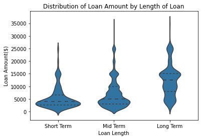

## Distribution of Loan Amount by Income Range

A bar plot was used to depict the relationship between the income range of borrowers and loan amount. The plot shows that borrowers having an income value within the \$75,000-100,000+ range take higher loan amounts, with borrowers that earn \\$100,000+ having the highest average loan amount, indicating that high-income earners are more likely to take high loan amounts.

[figure not shown]

## Distribution of Loan Status by Loan Amount and Loan Length

In the bar plot used to show the relationship between loan amount, loan status and loan length below, usually, for each term, the lower loan amounts can be seen to have a defaulted or charged off loan status. This supports the finding that lower loan amounts for each loan length, are more likely to be defaulted or charged off.

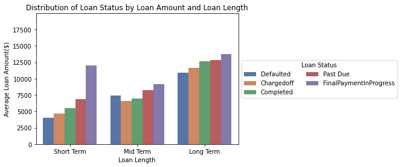

## Distribution of Loan Status by Interest Rate and Loan Length

The point plot visualizes the relationship between loan length, loan status, and interest rates.

For each loan length in the plot, generally, higher interest rate loans can be seen to have a defaulted or charged off or past due loan status, supporting the finding that for each loan length, loans with higher interest rates will likely get defaulted, charged off or not paid in time.

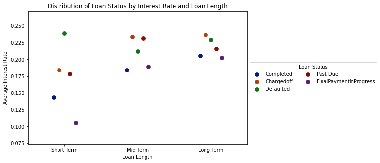